# COMPSCIX 415.2 Homework 9/Final

### Random forest (10 points)

On the last homework, we fit a decision tree to the Titanic data set to predict the probability of survival given the features. This week we’ll use the random forest and compare our results to the decision tree.

1. Randomly split your data into training and testing using the code below so that we all have the same sets.

```r
file_path <- '../data/homework9/train.csv'
train <- read_csv(file_path)
train <- train %>% mutate(Survived =
  factor(case_when(
                  Survived == 1 ~ 'True',
                  Survived == 0 ~ 'False'
                  ),
            levels = c('True', 'False')
         )
  )

train <- train %>% mutate(Sex =
  factor(case_when(
                  Sex == "male" ~ 'Man',
                  Sex == "female" ~ 'Woman'
               ),
            levels = c('Man', 'Woman')
         )
  )

train <- train %>% mutate(Pclass =
  factor(case_when(
                  Pclass == 1 ~ 'First',
                  Pclass == 2 ~ 'Second',
                  Pclass == 3 ~ 'Third'
                  ),
            levels = c('First', 'Second', 'Third')
         )
  )

train <- train %>% mutate(Embarked =
  factor(case_when(
                  Embarked == "C" ~ 'Cherbourg',
                  Embarked == "Q" ~ 'Queenstown',
                  Embarked == "S" ~ 'Southampton'
                  ),
            levels = c('Southampton', 'Cherbourg', 'Queenstown')
         )
  )

# set.seed(987)
# model_data <- resample_partition(train, c(test = 0.3, train = 0.7))
# train_set <- as.tibble(model_data$PassengerId)
# test_set <- as.tibble(model_data$PassengerId)

set.seed(29283)
train_set <- train %>% sample_frac(.7)
test_set <- train %>% filter(!(train$PassengerId %in% train_set$PassengerId))
```

2. Fit a decision tree to `train_set` using the `rpart` package, and using `Pclass`, `Sex`, `Age`, `SibSp`, `Parch`, `Fare`, `Embarked` as the features.
- Plot the tree using the `partykit` package.
- What do you notice about this tree compared to the one from last week which only contained three features?  
  *In both the tree form last week and the new trees, Sex and Pclass are still the strongest determinants of survival. For men, age emerges are more important than Fare. For women, Fare is more important than Age.*

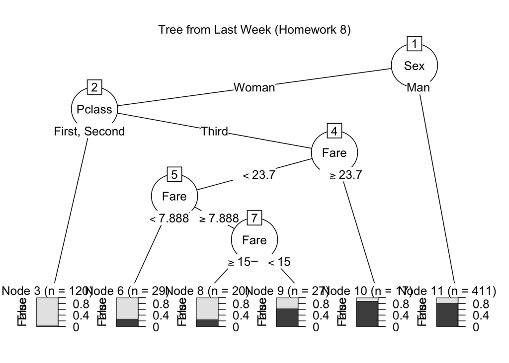

```r
tree_mod_old <- rpart(Survived ~ Pclass + Sex + Fare, data = train_set)
tree_mod <- rpart(Survived ~ Pclass + Sex + Age + SibSp + Parch + Fare + Embarked, data = train_set)

plot(as.party(tree_mod_old), main="Tree from Last Week (Homework 8)")
```

[figure not shown]

```r
plot(as.party(tree_mod), main="Tree for Final Exam (Homework 9)")
```

```r
rf_mod <- randomForest(Pclass ~ Sex + Age + SibSp + Parch + Fare + Embarked,
                         data = train_set,
                         ntrees = 500,
                         mtry = 4,
                         na.action = na.roughfix)
```

```r
library(ROCR)
rf_preds <- predict(rf_mod, newdata = test_set, type = 'prob')[,2]
tree_preds <- predict(tree_mod, newdata = test_set)[,2]

pred_rf <- prediction(predictions = rf_preds, labels = test_set$Survived)
pred_tree <- prediction(predictions = tree_preds, labels = test_set$Survived)
```

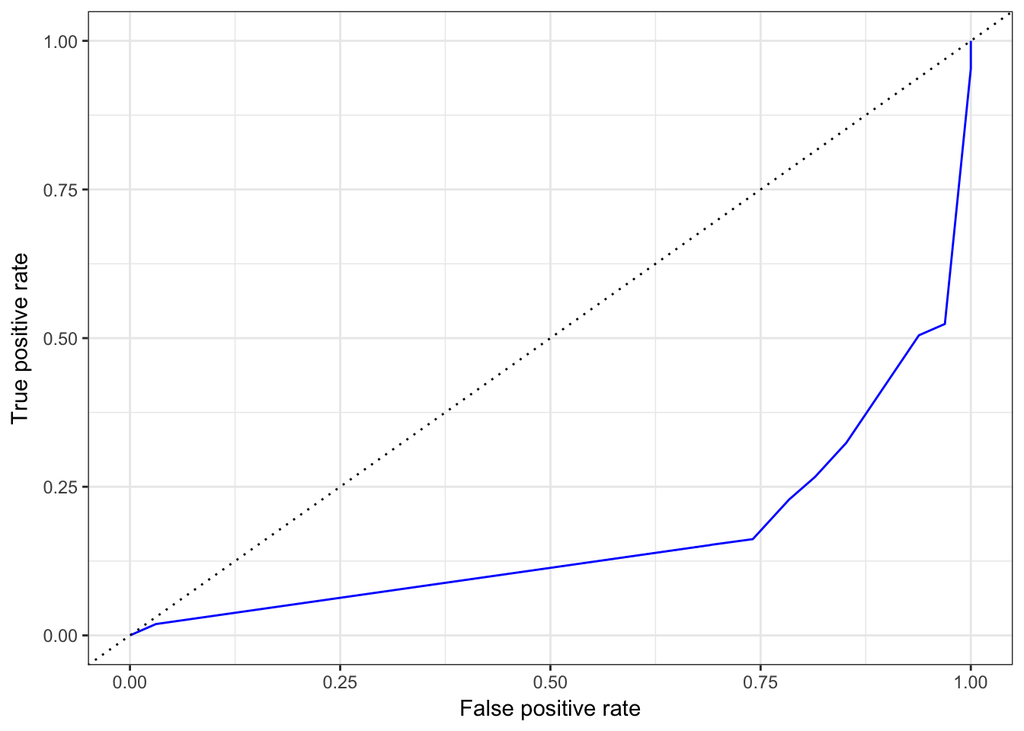

```r
# get the FPR and TPR for the logistic model
# recall that the ROC curve plots the FPR on the x-axis
perf_rf <- performance(pred_rf, measure = 'tpr', x.measure = 'fpr')
perf_rf_tbl <- tibble(perf_rf@x.values[[1]], perf_rf@y.values[[1]])

perf_tree <- performance(pred_tree, measure = 'tpr', x.measure = 'fpr')
# perf_tree_tbl <- tibble(pred_tree@x.values[[1]], pred_tree@y.values[[1]])

# Change the names of the columns of the tibble
names(perf_rf_tbl) <- c('fpr', 'tpr')

# get the FPR and TPR for the tree model
perf_tree <- performance(pred_tree, measure = 'tpr', x.measure = 'fpr')
perf_tree_tbl <- tibble(perf_tree@x.values[[1]], perf_tree@y.values[[1]])

# Change the names of the columns of the tibble
names(perf_tree_tbl) <- c('fpr', 'tpr')

# Plotting function for plotting a nice ROC curve using ggplot
plot_roc <- function(perf_tbl) {
  p <- ggplot(data = perf_tbl, aes(x = fpr, y = tpr)) +
    geom_line(color = 'blue') +
    geom_abline(intercept = 0, slope = 1, lty = 3) +
    labs(x = 'False positive rate', y = 'True positive rate') +
    theme_bw()
  return(p)
}

# Create the ROC curves using the function we created above
plot_roc(perf_tree_tbl)
```